# Normative Jump Data Malaysia

Samuel Montalvo, Ph.D.

11/20/2022

```r
library(readr)
library(dplyr)
library(ggplot2)
library(PupillometryR)
library(ggprism)
library(flextable)
library(officer)
library(table1)
library(janitor)
library(caret)
library(ggpubr)
library(plotly)
library(kableExtra)
library(htmlwidgets)
library(webshot)
library(ggcorrplot)
library(factoextra)
```

```r
Df <- read_csv("Project-Session-09_13_22-Session-09_13_22-AveragesAndTests_Countermovement_Jump.csv")
## Reduce jump trials to average
Df_average <- Df %>% filter(TestId == "AVERAGE")
Df_average <- clean_names(Df_average)
Df_average <- subset(Df_average, select = -c(test_id, date, time, segment, position, excluded, type, tags, rsi, flight_time,takeoff_velocity))
Df_average$'l_r_landing_impulse_index'<- as.numeric(Df_average$'l_r_landing_impulse_index')
Df_average$'time_to_stabilization'<- as.numeric(Df_average$'time_to_stabilization')
```

## Data Wrangling and Cleaning

Names of participants and sex needs to be join into the main jump dataset to have a complete dataset. New dataset is then saved into an csv document

```r
## import participant details
library(readxl)
Df_details <- read_excel("Athletes details SUKMA XX.xlsx")

# change capital name letters so that data sets match
Df_details <- Df_details %>% rename(name = NAME)

# re name males and females
Df_details$Sex <- recode_factor(Df_details$Sex,  F = "Female",
                                M = "Male")
# merge data sets by Name
Df <- inner_join(x=Df_details,y=Df_average,
                 by = "name")

## Subset NA
Df <- Df |>
  subset(!is.na(jump_height))

# convert spaces to _
Df <- clean_names(Df)

#remove names
Df <- subset(Df, select = -c(name))


write.csv(Df, "C:\\Users\\Samuel\\OneDrive\\Documents\\R\\SUKMA_Wushu\\SUKMA_Wushu_Data.csv", row.names = FALSE)
```

## Zscore

Creation and distribuition of the zscore. First need to create two data frames, one for males and one for females.

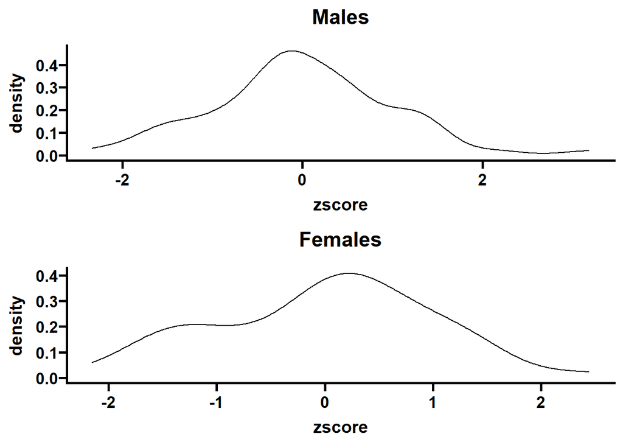

## Tscore for CMJ

next step is to create a tscore based on the zscore * 10 + 50 as recommended by the article. Then, a rank class is created based on the tscore. Lastly, factors are reorderd so that they appear in that order in the plots.

```r
# rank based on z score
Df_male <- Df_male%>% mutate(Tscore =  zscore*10+50)
Df_female <- Df_female%>% mutate(Tscore =  zscore*10+50)

Df_male <- Df_male %>% mutate(Description =
                            case_when(zscore > 2.0 ~ 'Excellent',
                             zscore <= 2.0 & zscore > 1.5  ~ 'Very Good',
                            zscore <= 1.5 & zscore > 1  ~ 'Good',
                            zscore <= 1 & zscore > 0.5  ~ 'Above Average',
                             zscore <= 0.5 & zscore > -0.5  ~ 'Average',
                             zscore <= -0.5 & zscore > -1.0  ~ 'Below Average',
                              zscore <= -1.0 & zscore > -1.5  ~ 'Poor',
                              zscore <= -1.5 & zscore > -2.0  ~ 'Very Poor',
                              zscore <= -2.0  ~ 'Extremely Poor'))

Df_male <- Df_male %>% mutate(Description_T =
                            case_when(Tscore > 80 ~ 'Excellent',
                                    Tscore < 81 & Tscore > 70  ~ 'Very Good',
                                    Tscore < 71 & Tscore > 60  ~ 'Good',
                                    Tscore < 61 & Tscore > 55  ~ 'Above Average',
                                    Tscore < 56 & Tscore > 45  ~ 'Average',
                                    Tscore < 46 & Tscore > 40  ~ 'Below Average',
                                    Tscore < 41 & Tscore > 30  ~ 'Poor',
                                    Tscore < 31 & Tscore > 20  ~ 'Very Poor',
                                    Tscore < 21  ~ 'Extremely Poor'))

Df_male$Description <- factor(Df_male$Description,
                             levels = c("Excellent", "Very Good", "Good",
                                        "Above Average", "Average",
                                        "Below Average","Poor",
                                        "Very Poor", "Extremely Poor"),
                             ordered = TRUE)

Df_female <- Df_female %>% mutate(Description =
                            case_when(zscore > 2.0 ~ 'Excellent',
                             zscore <= 2.0 & zscore > 1.5  ~ 'Very Good',
                            zscore <= 1.5 & zscore > 1  ~ 'Good',
                            zscore <= 1 & zscore > 0.5  ~ 'Above Average',
                             zscore <= 0.5 & zscore > -0.5  ~ 'Average',
                             zscore <= -0.5 & zscore > -1.0  ~ 'Below Average',
                              zscore <= -1.0 & zscore > -1.5  ~ 'Poor',
                              zscore <= -1.5 & zscore > -2.0  ~ 'Very Poor',
                              zscore <= -2.0  ~ 'Extremely Poor'))

Df_female <- Df_female %>% mutate(Description_T =
                            case_when(Tscore > 80 ~ 'Excellent',
                              Tscore < 81 & Tscore > 70  ~ 'Very Good',
                              Tscore < 71 & Tscore > 60  ~ 'Good',
                              Tscore < 61 & Tscore > 55  ~ 'Above Average',
                              Tscore < 56 & Tscore > 45  ~ 'Average',
                              Tscore < 46 & Tscore > 40  ~ 'Below Average',
                              Tscore < 41 & Tscore > 30  ~ 'Poor',
                              Tscore < 31 & Tscore > 20  ~ 'Very Poor',
                              Tscore < 21  ~ 'Extremely Poor'))

Df_female$Description <- factor(Df_female$Description,
                             levels = c("Excellent", "Very Good", "Good",
                                        "Above Average", "Average",
                                        "Below Average","Poor",
                                        "Very Poor", "Extremely Poor"),
                             ordered = TRUE)
```

##Interactive Plots

```r
p1 <- Df_male %>%
  ggplot(aes(y = jump_height, x = zscore, fill = Description)) +
  geom_point(position = position_jitter(width = .25), size = 4, shape = 21, color = "black") +
  scale_fill_manual(values = c("#006600", "#33CC33", "#00CC00",
                               "#ccffcc", "#FFFFFF", "#FFCC00",
                               "#CC3232", "#a32828", "#7a1e1e")) +
  theme_bw() +
  labs(title = "Male", y = "Jump Height (m)")

ggplotly(p1)
```

[interactive chart not shown]

Figure 1. Interactive plot of normative jump data for male athletes.

```r
#ggsave("p1.png")
```

```r
summary_male_table <- Df_male %>%
  group_by(Description) %>%
  summarise(`Number of Athletes` = n(),
            `Min Jump Height (cm)` = format(min(jump_height), digits = 2),
            `Max Jump Height (cm)` = format(max(jump_height), digits = 2))

summary_male_table$`Jump Height (cm) Range` <- ifelse(
  summary_male_table$Description == "Excellent",
  paste("> ", summary_male_table$`Min Jump Height (cm)`[summary_male_table$Description == "Excellent"]),

  ifelse(summary_male_table$Description == "Very Good",
    paste(summary_male_table$`Min Jump Height (cm)`[summary_male_table$Description == "Very Good"],  " - ",summary_male_table$`Min Jump Height (cm)`[summary_male_table$Description == "Excellent"]
    ),
    ifelse(summary_male_table$Description == "Good",
            paste(summary_male_table$`Min Jump Height (cm)`[summary_male_table$Description == "Good"], " - ", summary_male_table$`Min Jump Height (cm)`[summary_male_table$Description == "Very Good"]),

        ifelse(
          summary_male_table$Description == "Above Average",
          paste(summary_male_table$`Min Jump Height (cm)`[summary_male_table$Description == "Above Average"], " - ", summary_male_table$`Min Jump Height (cm)`[summary_male_table$Description == "Good"]),

        ifelse(
          summary_male_table$Description == "Average",
          paste(summary_male_table$`Min Jump Height (cm)`[summary_male_table$Description == "Average"], " - ", summary_male_table$`Min Jump Height (cm)`[summary_male_table$Description == "Above Average"]),

               ifelse(
          summary_male_table$Description == "Below Average",
          paste(summary_male_table$`Min Jump Height (cm)`[summary_male_table$Description == "Below Average"], " - ", summary_male_table$`Min Jump Height (cm)`[summary_male_table$Description == "Average"]),

      ifelse(
        summary_male_table$Description == "Poor",
        paste(summary_male_table$`Min Jump Height (cm)`[summary_male_table$Description == "Poor"], " - ", summary_male_table$`Min Jump Height (cm)`[summary_male_table$Description == "Below Average"]),

      ifelse(
        summary_male_table$Description == "Very Poor",
        paste(summary_male_table$`Min Jump Height (cm)`[summary_male_table$Description == "Very Poor"], " - ", summary_male_table$`Min Jump Height (cm)`[summary_male_table$Description == "Poor"]),

    ifelse(
      summary_male_table$Description == "Extremely Poor",
      paste("< ", summary_male_table$`Min Jump Height (cm)`[summary_male_table$Description == "Very Poor"]),



              paste(summary_male_table$`Min Jump Height (cm)`, " - ", summary_male_table$`Max Jump Height (cm)`)
            )
          )
        )
      )
    )
  )
)
))

summary_male_table$Description <- factor(summary_male_table$Description,
                                         levels = c("Excellent", "Very Good", "Good", "Above Average", "Average", "Below Average", "Poor", "Very Poor","Extremely Poor"))

summary_male_table <- summary_male_table %>%
  select(-`Min Jump Height (cm)`, -`Max Jump Height (cm)`) %>%
  kable("html", align = "c") %>%
  column_spec(1:3, bold = TRUE) %>%
  row_spec(1:8, bold = TRUE) %>%
  kable_styling(full_width = TRUE) %>%
  row_spec(which(summary_male_table$Description == "Excellent"), background = "#00AA00") %>%
  row_spec(which(summary_male_table$Description == "Very Good"), background = "#00CC00") %>%
  row_spec(which(summary_male_table$Description == "Good"), background = "#00EE00") %>%
  row_spec(which(summary_male_table$Description == "Above Average"), background = "#99FF99") %>%
  row_spec(which(summary_male_table$Description == "Average"), background = "#FFFFFF") %>%
  row_spec(which(summary_male_table$Description == "Below Average"), background = "#FFF000") %>%
  row_spec(which(summary_male_table$Description == "Poor"), background = "#FF0000") %>%
  row_spec(which(summary_male_table$Description == "Very Poor"), background = "#CC0000") %>%
  row_spec(which(summary_male_table$Description == "Extremely Poor"), background = "#990000")

summary_male_table
```

| Description | Number of Athletes | Jump Height (cm) Range |
| --- | --- | --- |
| Excellent | 2 | > 0.62 |
| Very Good | 1 | 0.58 - 0.62 |
| Good | 9 | 0.55 - 0.58 |
| Above Average | 6 | 0.52 - 0.55 |
| Average | 32 | 0.47 - 0.52 |
| Below Average | 7 | 0.44 - 0.47 |
| Poor | 5 | 0.41 - 0.44 |
| Very Poor | 4 | 0.38 - 0.41 |
| Extremely Poor | 1 | < 0.38 |

```r
p2 <- Df_female %>%
  ggplot(aes(y = jump_height, x = zscore, fill = Description)) +
  geom_point(position = position_jitter(width = .25), size = 4, shape = 21, color = "black") +
  scale_fill_manual(values = c("#006600", "#33CC33", "#00CC00",
                               "#ccffcc", "#FFFFFF", "#FFCC00",
                               "#CC3232", "#a32828", "#7a1e1e")) +
  theme_bw() +
  labs(title = "Female", y = "Jump Height (m)")

ggplotly(p2)
```

[interactive chart not shown]

```r
#ggsave("p2.png")
```

Notice that we don’t have a “very good” due to the zscore and the low sample size, those that section has been silenced (#), this should be improved with a larger sample size. For a larger sample remove the #, and add a closure “)”

```r
summary_female_table <- Df_female %>%
  group_by(Description) %>%
  summarise(
    `Number of Athletes` = n(),
    `Min Jump Height (cm)` = format(min(jump_height), digits = 2),
    `Max Jump Height (cm)` = format(max(jump_height), digits = 2)
  )

summary_female_table$`Jump Height (cm) Range` <- ifelse(
  summary_female_table$Description == "Excellent",
  paste("> ", summary_female_table$`Min Jump Height (cm)`[summary_female_table$Description == "Excellent"]),

  #ifelse(summary_female_table$Description == "Very Good",
    #paste(summary_female_table$`Min Jump Height (cm)`[summary_female_table$Description == "Very Good"],  " - ",summary_female_table$`Min Jump Height (cm)`[summary_female_table$Description == "Excellent"]
    #),
    ifelse(summary_female_table$Description == "Good",
            paste(summary_female_table$`Min Jump Height (cm)`[summary_female_table$Description == "Good"], " - ", summary_female_table$`Min Jump Height (cm)`[summary_female_table$Description == "Excellent"]),

        ifelse(
          summary_female_table$Description == "Above Average",
          paste(summary_female_table$`Min Jump Height (cm)`[summary_female_table$Description == "Above Average"], " - ", summary_female_table$`Min Jump Height (cm)`[summary_female_table$Description == "Good"]),

        ifelse(
          summary_female_table$Description == "Average",
          paste(summary_female_table$`Min Jump Height (cm)`[summary_female_table$Description == "Average"], " - ", summary_female_table$`Min Jump Height (cm)`[summary_female_table$Description == "Above Average"]),

               ifelse(
          summary_female_table$Description == "Below Average",
          paste(summary_female_table$`Min Jump Height (cm)`[summary_female_table$Description == "Below Average"], " - ", summary_female_table$`Min Jump Height (cm)`[summary_female_table$Description == "Average"]),

      ifelse(
        summary_female_table$Description == "Poor",
        paste(summary_female_table$`Min Jump Height (cm)`[summary_female_table$Description == "Poor"], " - ", summary_female_table$`Min Jump Height (cm)`[summary_female_table$Description == "Below Average"]),

      ifelse(
        summary_female_table$Description == "Very Poor",
        paste(summary_female_table$`Min Jump Height (cm)`[summary_female_table$Description == "Very Poor"], " - ", summary_female_table$`Min Jump Height (cm)`[summary_female_table$Description == "Poor"]),

    ifelse(
      summary_female_table$Description == "Extremely Poor",
      paste("< ", summary_female_table$`Min Jump Height (cm)`[summary_female_table$Description == "Very Poor"]),

              paste(summary_female_table$`Min Jump Height (cm)`, " - ", summary_female_table$`Max Jump Height (cm)`)
            )
          )
        )
      )
    )
  )
)
)

summary_female_table$Description <- factor(
  summary_female_table$Description,
  levels = c(
    "Excellent",
    "Very Good",
    "Good",
    "Above Average",
    "Average",
    "Below Average",
    "Poor",
    "Very Poor",
    "Extremely Poor"
  )
)

summary_female_table <- summary_female_table %>%
  select(-`Min Jump Height (cm)`, -`Max Jump Height (cm)`) %>%
  kable("html", align = "c") %>%
  column_spec(1:3, bold = TRUE) %>%
  row_spec(1:8, bold = TRUE) %>%
  kable_styling(full_width = TRUE) %>%
  row_spec(which(summary_female_table$Description == "Excellent"), background = "#00AA00") %>%
  row_spec(which(summary_female_table$Description == "Very Good"), background = "#00CC00") %>%
  row_spec(which(summary_female_table$Description == "Good"), background = "#00EE00") %>%
  row_spec(which(summary_female_table$Description == "Above Average"), background = "#99FF99") %>%
  row_spec(which(summary_female_table$Description == "Average"), background = "#FFFFFF") %>%
  row_spec(which(summary_female_table$Description == "Below Average"), background = "#FFF000") %>%
  row_spec(which(summary_female_table$Description == "Poor"), background = "#FF0000") %>%
  row_spec(which(summary_female_table$Description == "Very Poor"), background = "#CC0000") %>%
  row_spec(which(summary_female_table$Description == "Extremely Poor"), background = "#990000")

summary_female_table
```

| Description | Number of Athletes | Jump Height (cm) Range |
| --- | --- | --- |
| Excellent | 1 | > 0.49 |
| Good | 7 | 0.42 - 0.49 |
| Above Average | 8 | 0.4 - 0.42 |
| Average | 18 | 0.35 - 0.4 |
| Below Average | 4 | 0.33 - 0.35 |
| Poor | 6 | 0.3 - 0.33 |
| Very Poor | 3 | 0.29 - 0.3 |
| Extremely Poor | 1 | < 0.29 |

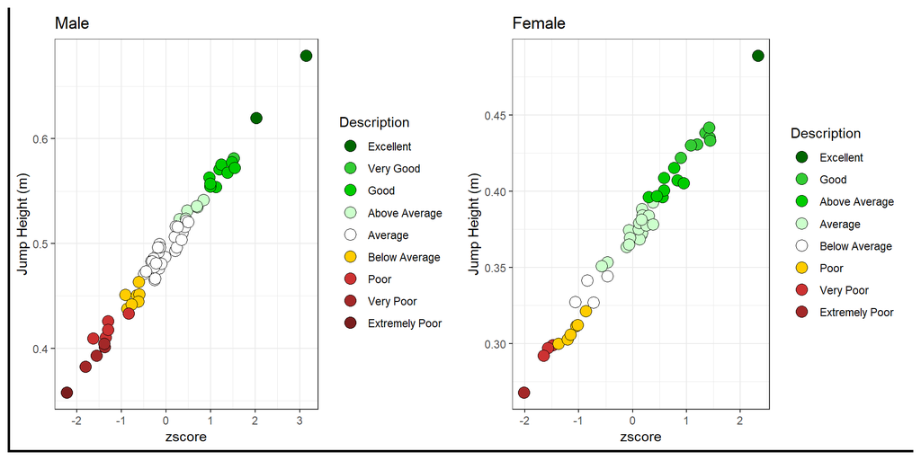

```r
ggarrange(p1,p2)+ theme_prism()
```

```r
ggsave("normative_bysex.png")
```

## Distribuition of Jump Height by groups

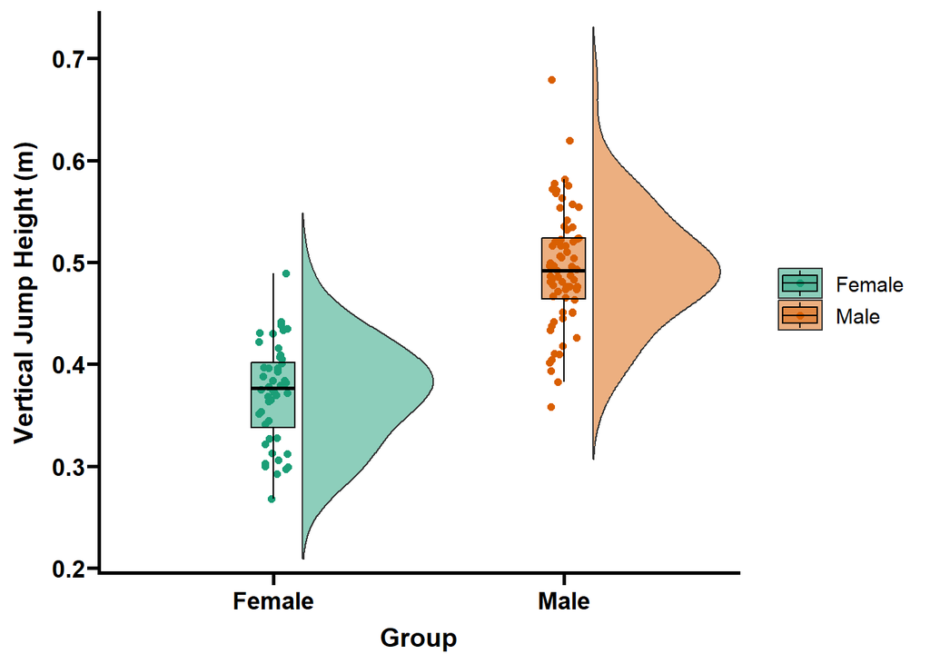

```r
p3 <- Df %>% ggplot(aes(x = sex, y = jump_height, fill = sex)) +
  geom_flat_violin(aes(fill = sex),
      position = position_nudge(x =.1, y=0), adjust = 1.5,trim = F, alpha =.5) +
  geom_point(aes(x=sex, y=jump_height,colour=sex),
             position = position_jitter(width = .05), size = 2.5, shape = 20)+
  geom_boxplot(aes(x = sex, y = jump_height, fill = sex),outlier.shape
               = NA, alpha = .5, width = .15, colour = "black")+
  coord_cartesian(ylim=c(0.22,0.72)) +
  scale_colour_brewer(palette = "Dark2")+
  scale_fill_brewer(palette = "Dark2")+ theme_bw() +
  ylab('Vertical Jump Height (m)')+
  xlab('Group') + theme_prism()
p3
```

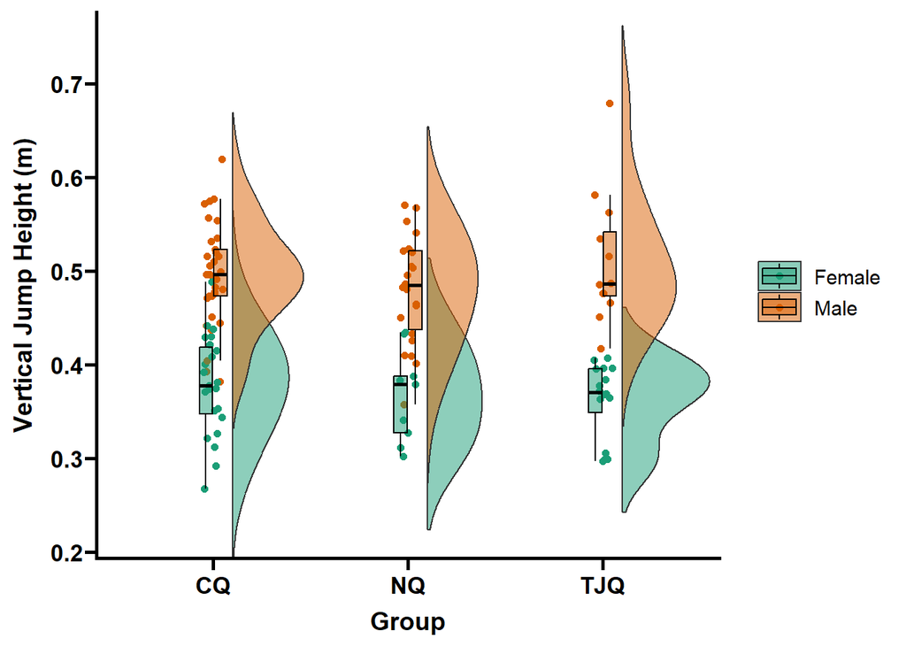

```r
p4 <- Df %>% ggplot(aes(x = events, y = jump_height, fill = sex)) +
  geom_flat_violin(aes(fill = sex),
                   position = position_nudge(x =.1, y=0), adjust = 1.5,trim = F, alpha =.5) +
  geom_point(aes(x=events, y=jump_height,colour=sex),
             position = position_jitter(width = .05), size = 2.5, shape = 20)+
  geom_boxplot(aes(x = events, y = jump_height, fill = sex),outlier.shape
               = NA, alpha = .5, width = .15, colour = "black")+
  coord_cartesian(ylim=c(0.22,0.75)) +
  scale_colour_brewer(palette = "Dark2")+
  scale_fill_brewer(palette = "Dark2")+ theme_bw() +
  ylab('Vertical Jump Height (m)')+
  xlab('Group') + theme_prism()
p4
```

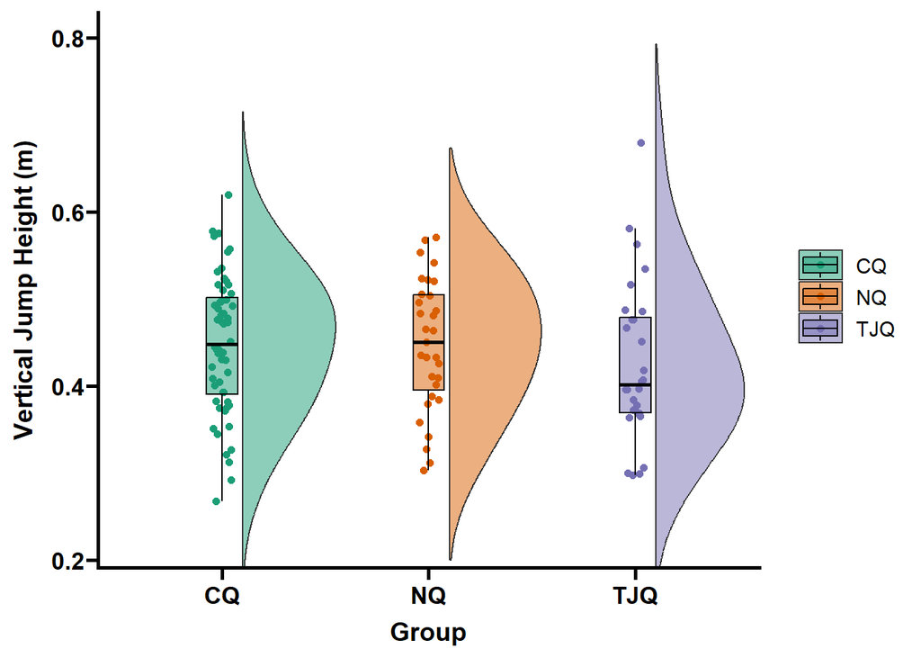

```r
p5 <- Df %>% ggplot(aes(x = events, y = jump_height, fill = events)) +
  geom_flat_violin(aes(fill = events),
                   position = position_nudge(x =.1, y=0), adjust = 1.5,trim = F, alpha =.5) +
  geom_point(aes(x=events, y=jump_height,colour=events),
             position = position_jitter(width = .05), size = 2.5, shape = 20)+
  geom_boxplot(aes(x = events, y = jump_height, fill = events),outlier.shape
               = NA, alpha = .5, width = .15, colour = "black")+
  coord_cartesian(ylim=c(0.22,0.8)) +
  scale_colour_brewer(palette = "Dark2")+
  scale_fill_brewer(palette = "Dark2")+ theme_bw() +
  ylab('Vertical Jump Height (m)')+
  xlab('Group') + theme_prism()
p5
```

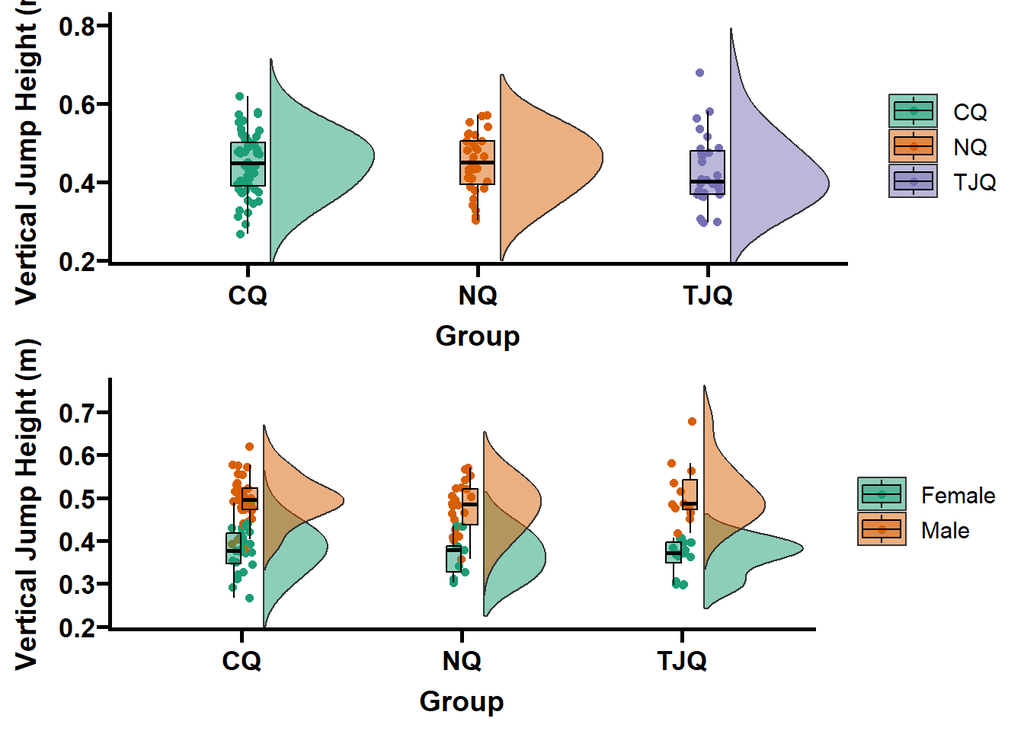

```r
ggarrange(p5,p4, ncol = 1)
```

```r
table1(~jump_height + jump_momentum +
         m_rsi + stiffness + positive_net_impulse | sex, data=Df )
```

|  | Female (N=48) | Male (N=67) | Overall (N=115) |
| --- | --- | --- | --- |
| jump_height |  |  |  |
| Mean (SD) | 0.371 (0.0480) | 0.494 (0.0582) | 0.443 (0.0812) |
| Median [Min, Max] | 0.376 [0.268, 0.489] | 0.492 [0.358, 0.679] | 0.442 [0.268, 0.679] |
| jump_momentum |  |  |  |
| Mean (SD) | 136 (16.8) | 187 (24.6) | 166 (33.5) |
| Median [Min, Max] | 137 [103, 177] | 183 [127, 232] | 164 [103, 232] |
| m_rsi |  |  |  |
| Mean (SD) | 0.437 (0.0862) | 0.557 (0.102) | 0.507 (0.112) |
| Median [Min, Max] | 0.437 [0.261, 0.621] | 0.564 [0.245, 0.816] | 0.506 [0.245, 0.816] |
| stiffness |  |  |  |
| Mean (SD) | -3470 (789) | -3930 (826) | -3740 (839) |
| Median [Min, Max] | -3300 [-5050, -1780] | -3890 [-5830, -1760] | -3670 [-5830, -1760] |
| positive_net_impulse |  |  |  |
| Mean (SD) | 208 (28.6) | 277 (39.1) | 248 (48.7) |
| Median [Min, Max] | 209 [151, 284] | 272 [179, 356] | 244 [151, 356] |

## Zscore for RSI

Creation and distribution of the zscore. First need to create two data frames, one for males and one for females.

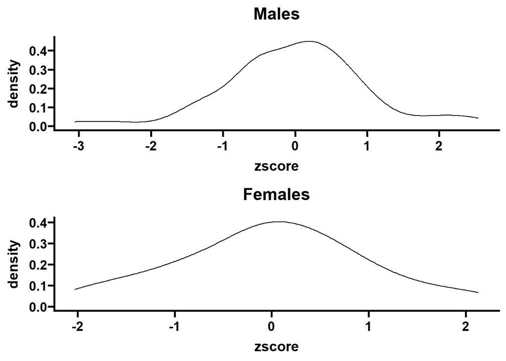

## Tscore for RSI

next step is to create a tscore for mrsi based on the zscore * 10 + 50 as recommended by the article. Then, a rank class is created based on the tscore. Lastly, factors are reorderd so that they appear in that order in the plots.

```r
# rank based on T score
Df_male_mrsi <- Df_male_mrsi%>% mutate(Tscore =  zscore*10+50)
Df_female_mrsi <- Df_female_mrsi%>% mutate(Tscore =  zscore*10+50)

Df_male_mrsi <- Df_male_mrsi %>% mutate(Description =
                            case_when(Tscore > 80 ~ 'Excellent',
                                    Tscore < 81 & Tscore > 70  ~ 'Very Good',
                                    Tscore < 71 & Tscore > 60  ~ 'Good',
                                    Tscore < 61 & Tscore > 55  ~ 'Above Average',
                                    Tscore < 56 & Tscore > 45  ~ 'Average',
                                    Tscore < 46 & Tscore > 40  ~ 'Below Average',
                                    Tscore < 41 & Tscore > 30  ~ 'Poor',
                                    Tscore < 31 & Tscore > 20  ~ 'Very Poor',
                                    Tscore < 21  ~ 'Extremely Poor'))

Df_male_mrsi$Description <- factor(Df_male_mrsi$Description,
                             levels = c("Excellent", "Very Good", "Good",
                                        "Above Average", "Average",
                                        "Below Average","Poor",
                                        "Very Poor", "Extremely Poor"),
                             ordered = TRUE)


Df_female_mrsi <- Df_female_mrsi %>% mutate(Description =
                            case_when(Tscore > 80 ~ 'Excellent',
                                    Tscore < 81 & Tscore > 70  ~ 'Very Good',
                                    Tscore < 71 & Tscore > 60  ~ 'Good',
                                    Tscore < 61 & Tscore > 55  ~ 'Above Average',
                                    Tscore < 56 & Tscore > 45  ~ 'Average',
                                    Tscore < 46 & Tscore > 40  ~ 'Below Average',
                                    Tscore < 41 & Tscore > 30  ~ 'Poor',
                                    Tscore < 31 & Tscore > 20  ~ 'Very Poor',
                                    Tscore < 21  ~ 'Extremely Poor'))

Df_female_mrsi$Description <- factor(Df_female_mrsi$Description,
                             levels = c("Excellent", "Very Good", "Good",
                                        "Above Average", "Average",
                                        "Below Average","Poor",
                                        "Very Poor", "Extremely Poor"),
                             ordered = TRUE)
```

##Interactive Plots

```r
p6 <- Df_male_mrsi %>% ggplot(y=m_rsi,x=zscore) +
  geom_point(aes(y=m_rsi,x=zscore,colour=Description),
             position = position_jitter(width = .25), size = 4, shape=20) +
   scale_color_manual(values = c("#125016", "#1b7821", "#24a02c",
                                "#125016", "#000000", "#e7b416",
                                "#CC3232","#a32828","#7a1e1e")) +
  theme_bw() + labs(title="Male",y="Modified Reactive Strength Index")

ggplotly(p6)
```

[interactive chart not shown]

```r
p7 <- Df_female_mrsi %>% ggplot(y=m_rsi,x=zscore) +
  geom_point(aes(y=m_rsi,x=zscore,colour=Description),
             position = position_jitter(width = .25), size = 4, shape=20) +
   scale_color_manual(values = c("#125016", "#1b7821", "#24a02c",
                                "#125016", "#000000", "#e7b416",
                                "#CC3232","#a32828","#7a1e1e")) +
  theme_bw() + labs(title="Female",y="Modified Reactive Strength Index")

ggplotly(p7)
```

[interactive chart not shown]

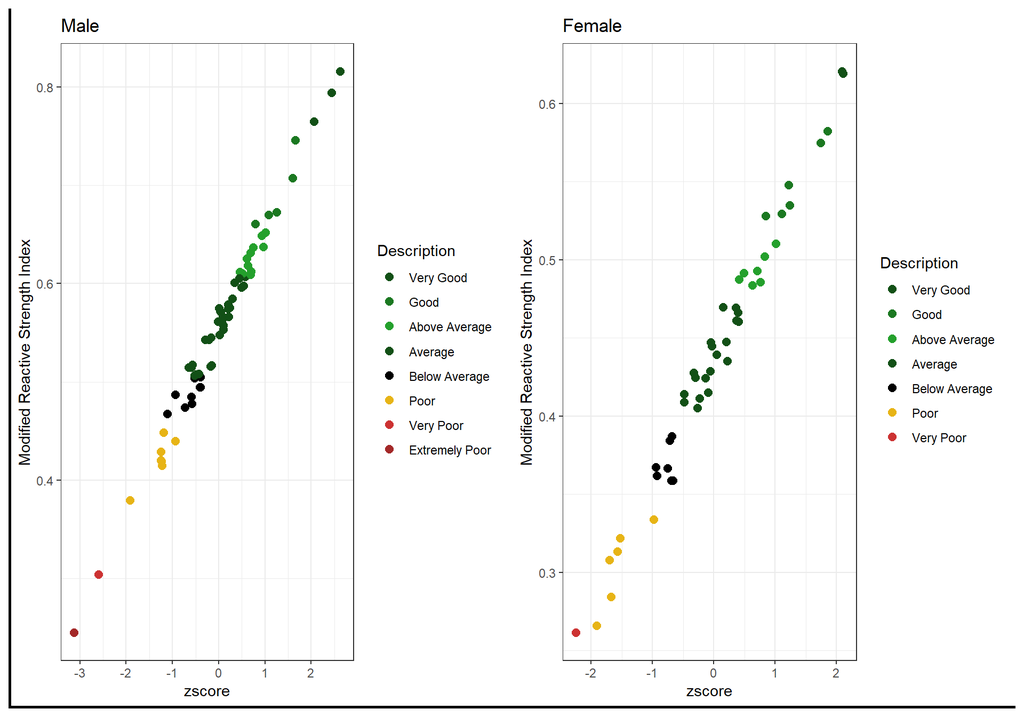

```r
ggarrange(p6,p7) + theme_prism()
```

```r
ggsave("normative_mrsi_bysex.png")
```

```r
df_jump_reduced_numerical <- Df[, 10:83]
# Convert all columns to numeric
df_jump_reduced_numerical <- data.frame(lapply(df_jump_reduced_numerical, function(x) as.numeric(as.character(x))))
```

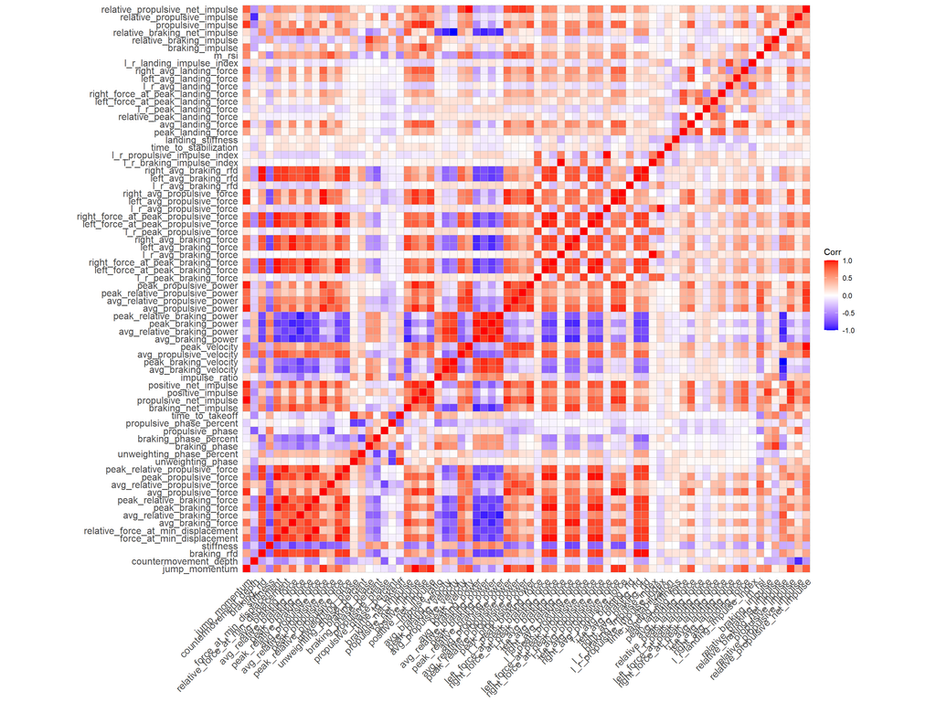

```r
df_jump_reduced_numerical <- scale(df_jump_reduced_numerical)
corr_matrix <- cor(df_jump_reduced_numerical, use="complete.obs")
ggcorrplot(corr_matrix)
```

```r
data.pca <- princomp(corr_matrix)
summary(data.pca)
```

```
## Importance of components:
##                           Comp.1     Comp.2    Comp.3     Comp.4     Comp.5
## Standard deviation     3.0680060 1.09561279 0.8344215 0.55458296 0.48550661
## Proportion of Variance 0.7698595 0.09817779 0.0569469 0.02515545 0.01927922
## Cumulative Proportion  0.7698595 0.86803730 0.9249842 0.95013965 0.96941886
##                            Comp.6      Comp.7      Comp.8      Comp.9
## Standard deviation     0.35901072 0.291021368 0.253517771 0.168837494
## Proportion of Variance 0.01054178 0.006927058 0.005256733 0.002331508
## Cumulative Proportion  0.97996064 0.986887700 0.992144433 0.994475941
##                            Comp.10     Comp.11      Comp.12     Comp.13
## Standard deviation     0.153957622 0.128868238 0.1061731509 0.086011428
## Proportion of Variance 0.001938659 0.001358285 0.0009219948 0.000605078
## Cumulative Proportion  0.996414600 0.997772885 0.9986948795 0.999299958
##                             Comp.14      Comp.15      Comp.16      Comp.17
## Standard deviation     0.0621456732 0.0502719912 3.049184e-02 2.496177e-02
## Proportion of Variance 0.0003158791 0.0002067051 7.604423e-05 5.096239e-05
## Cumulative Proportion  0.9996158366 0.9998225418 9.998986e-01 9.999495e-01
##                             Comp.18      Comp.19      Comp.20      Comp.21
## Standard deviation     0.0189660860 9.801895e-03 8.839526e-03 4.885771e-03
## Proportion of Variance 0.0000294208 7.858130e-06 6.390826e-06 1.952384e-06
## Cumulative Proportion  0.9999789692 9.999868e-01 9.999932e-01 9.999952e-01
##                             Comp.22      Comp.23      Comp.24      Comp.25
## Standard deviation     4.421451e-03 2.898816e-03 2.737587e-03 2.393806e-03
## Proportion of Variance 1.598927e-06 6.872905e-07 6.129638e-07 4.686805e-07
## Cumulative Proportion  9.999968e-01 9.999975e-01 9.999981e-01 9.999985e-01
##                             Comp.26      Comp.27      Comp.28      Comp.29
## Standard deviation     2.232892e-03 1.649348e-03 1.631149e-03 1.282867e-03
## Proportion of Variance 4.077882e-07 2.224967e-07 2.176137e-07 1.346053e-07
## Cumulative Proportion  9.999989e-01 9.999992e-01 9.999994e-01 9.999995e-01
##                             Comp.30      Comp.31      Comp.32      Comp.33
## Standard deviation     1.233158e-03 1.113051e-03 9.437413e-04 8.585304e-04
## Proportion of Variance 1.243759e-07 1.013280e-07 7.284588e-08 6.028516e-08
## Cumulative Proportion  9.999996e-01 9.999997e-01 9.999998e-01 9.999999e-01
##                             Comp.34      Comp.35      Comp.36      Comp.37
## Standard deviation     7.880441e-04 5.375779e-04 4.296498e-04 3.714300e-04
## Proportion of Variance 5.079256e-08 2.363643e-08 1.509831e-08 1.128374e-08
## Cumulative Proportion  9.999999e-01 1.000000e+00 1.000000e+00 1.000000e+00
##                             Comp.38      Comp.39      Comp.40      Comp.41
## Standard deviation     2.849653e-04 2.643565e-04 2.096511e-04 1.390099e-04
## Proportion of Variance 6.641759e-09 5.715828e-09 3.594954e-09 1.580487e-09
```

[output cut: 18 more lines]

```
## Standard deviation     8.896039e-07 7.563176e-07 1.074345e-07 2.348365e-08
## Proportion of Variance 6.472803e-14 4.678509e-14 9.440325e-16 4.510559e-17
## Cumulative Proportion  1.000000e+00 1.000000e+00 1.000000e+00 1.000000e+00
##                             Comp.62      Comp.63      Comp.64      Comp.65
## Standard deviation     1.920058e-08 1.447768e-08 4.014930e-09 3.870902e-09
## Proportion of Variance 3.015281e-17 1.714341e-17 1.318424e-18 1.225528e-18
## Cumulative Proportion  1.000000e+00 1.000000e+00 1.000000e+00 1.000000e+00
##                             Comp.66 Comp.67 Comp.68 Comp.69 Comp.70 Comp.71
## Standard deviation     1.383843e-09       0       0       0       0       0
## Proportion of Variance 1.566292e-19       0       0       0       0       0
## Cumulative Proportion  1.000000e+00       1       1       1       1       1
##                        Comp.72 Comp.73 Comp.74
## Standard deviation           0       0       0
## Proportion of Variance       0       0       0
## Cumulative Proportion        1       1       1
```

```r
# Get the loadings for the first four principal components
data.pca$loadings[, 3:3]
```

```
##                        jump_momentum                countermovement_depth
##                          0.024332631                         -0.244210680
##                          braking_rfd                            stiffness
##                          0.024303734                          0.147711764
##            force_at_min_displacement   relative_force_at_min_displacement
##                          0.035015446                          0.031117410
##                    avg_braking_force           avg_relative_braking_force
##                         -0.028617452                         -0.062505970
##                   peak_braking_force          peak_relative_braking_force
##                          0.035113643                          0.031022853
##                 avg_propulsive_force        avg_relative_propulsive_force
##                         -0.066381216                         -0.189357447
##                peak_propulsive_force       peak_relative_propulsive_force
##                          0.058370298                          0.063028323
##                    unweighting_phase            unweighting_phase_percent
##                          0.217355884                          0.043293166
##                        braking_phase                braking_phase_percent
##                          0.206551556                          0.011951446
##                     propulsive_phase             propulsive_phase_percent
##                          0.280484119                         -0.082190032
##                      time_to_takeoff                  braking_net_impulse
##                          0.279054308                         -0.016667488
##               propulsive_net_impulse                     positive_impulse
##                          0.024459341                          0.152586091
##                 positive_net_impulse                        impulse_ratio
##                          0.010573646                          0.120819294
##                 avg_braking_velocity                peak_braking_velocity
##                          0.003316029                          0.039767062
##              avg_propulsive_velocity                        peak_velocity
##                          0.009376006                          0.020263261
##                    avg_braking_power           avg_relative_braking_power
##                          0.008652310                          0.020075888
##                   peak_braking_power          peak_relative_braking_power
##                          0.004476509                          0.014517207
##                 avg_propulsive_power        avg_relative_propulsive_power
##                         -0.037433011                         -0.080679052
##       peak_relative_propulsive_power                peak_propulsive_power
##                         -0.047497075                         -0.014039812
##               l_r_peak_braking_force     left_force_at_peak_braking_force
##                         -0.192176755                          0.002601037
```

[output cut: 19 more lines]

```
##                         -0.010515056                         -0.152743952
##               l_r_peak_landing_force     left_force_at_peak_landing_force
##                         -0.080023037                         -0.145892271
##    right_force_at_peak_landing_force                l_r_avg_landing_force
##                         -0.059586803                         -0.089471715
##               left_avg_landing_force              right_avg_landing_force
##                         -0.061192527                          0.036863275
##            l_r_landing_impulse_index                                m_rsi
##                         -0.126381572                         -0.161221275
##                      braking_impulse             relative_braking_impulse
##                          0.176740309                          0.223412058
##         relative_braking_net_impulse                   propulsive_impulse
##                         -0.040848792                          0.122064479
##          relative_propulsive_impulse      relative_propulsive_net_impulse
##                          0.251324940                          0.018289322
```

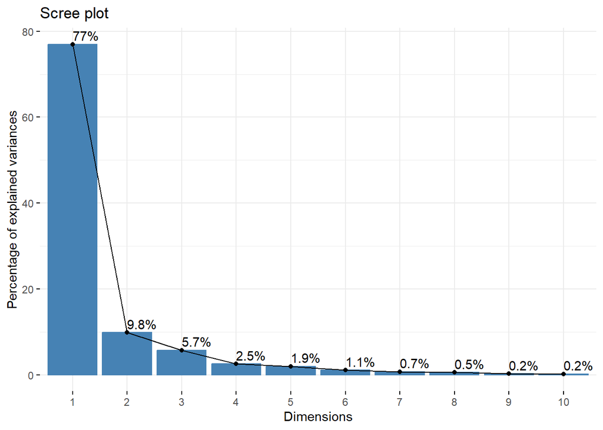

```r
fviz_eig(data.pca, addlabels = TRUE)
```

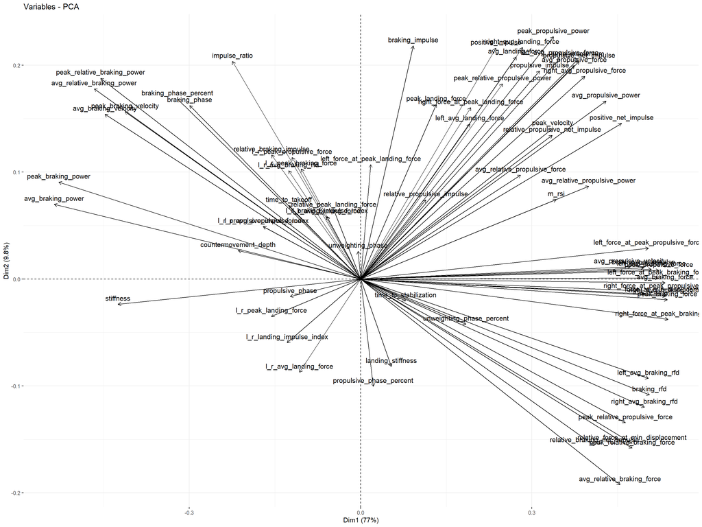

```r
# Graph of the variables
fviz_pca_var(data.pca, col.var = "black")
```

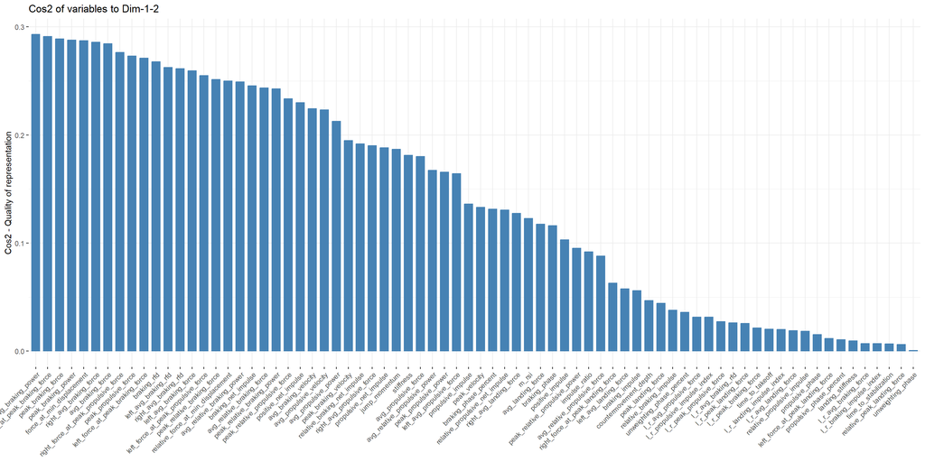

```r
fviz_cos2(data.pca, choice = "var", axes = 1:2)
```

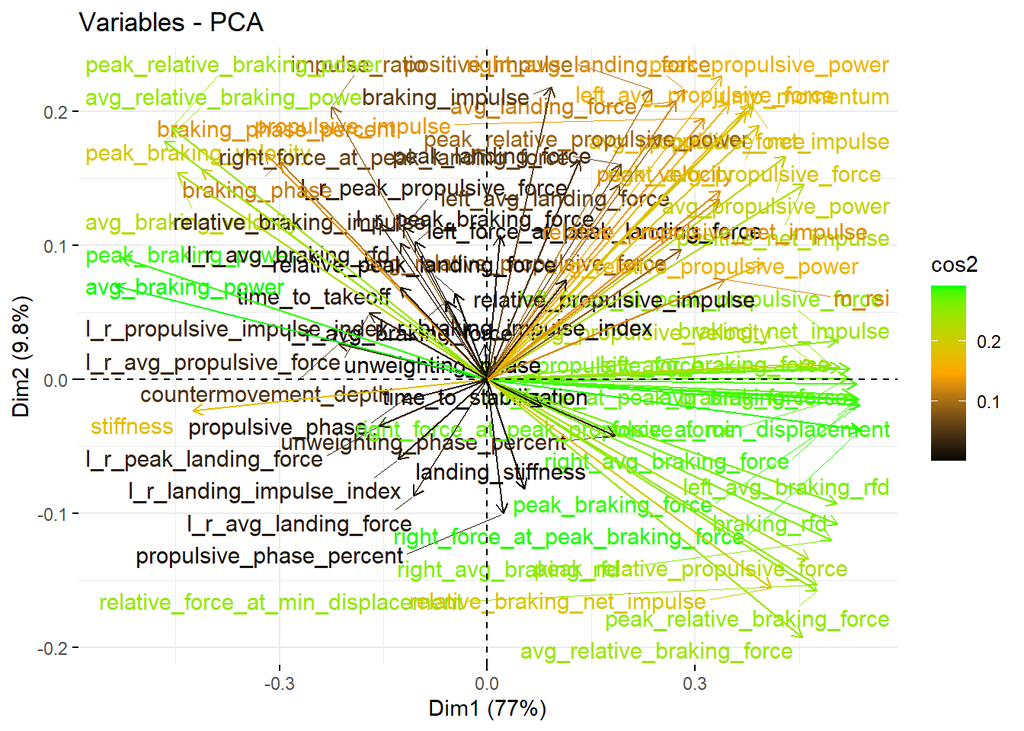

```r
fviz_pca_var(data.pca, col.var = "cos2",
            gradient.cols = c("black", "orange", "green"),
            repel = TRUE)
```

```r
# Assume that 'data.pca' is your PCA result
# Set the threshold
threshold = 0.2

# Get the loadings for the first four principal components
loadings <- data.pca$loadings[, 1:3]

# Find the names of variables where the absolute value of the loading is greater than the threshold in any of the first four components
important_variables <- which(apply(loadings, 1, function(x) any(abs(x) > threshold)))

# If your data.pca was generated by prcomp or princomp, use the following code to extract important variables
# important_variables <- rownames(loadings)[apply(loadings, 1, function(x) any(abs(x) > threshold))]

# Assume that your dataframe is called df
# Create a new dataframe with only these variables
new_df <- Df[, important_variables]

# Print out the new dataframe
print(new_df)
```

```
## # A tibble: 115 × 8
##    region relative_force_at_min_…¹ avg_relative_braking…² peak_relative_brakin…³
##    <chr>                     <dbl>                  <dbl>                  <dbl>
##  1 PRK                        248.                   186.                   249.
##  2 SBH                        265.                   178.                   265.
##  3 JHR                        253.                   174.                   253.
##  4 PLS                        220.                   186.                   220.
##  5 MLK                        294.                   192.                   294.
##  6 MLK                        463.                   248.                   464.
##  7 SWK                        240.                   181.                   240.
##  8 SGR                        265.                   186.                   264.
##  9 PHG                        266.                   170.                   265.
## 10 PLS                        254.                   157.                   254.
## # ℹ 105 more rows
## # ℹ abbreviated names: ¹relative_force_at_min_displacement,
## #   ²avg_relative_braking_force, ³peak_relative_braking_force
## # ℹ 4 more variables: avg_relative_propulsive_force <dbl>,
## #   avg_propulsive_velocity <dbl>, l_r_peak_landing_force <dbl>,
## #   l_r_avg_landing_force <dbl>
```

```r
library(table1)
table1(~ age + jump_height + m_rsi  | sex, data= Df, overall=FALSE)
```

|  | Female (N=48) | Male (N=67) |
| --- | --- | --- |
| age |  |  |
| Mean (SD) | 17.4 (2.76) | 18.1 (2.36) |
| Median [Min, Max] | 17.0 [13.0, 23.0] | 18.0 [13.0, 23.0] |
| jump_height |  |  |
| Mean (SD) | 0.371 (0.0480) | 0.494 (0.0582) |
| Median [Min, Max] | 0.376 [0.268, 0.489] | 0.492 [0.358, 0.679] |
| m_rsi |  |  |
| Mean (SD) | 0.437 (0.0862) | 0.557 (0.102) |
| Median [Min, Max] | 0.437 [0.261, 0.621] | 0.564 [0.245, 0.816] |

```r
# Fit the linear mixed model
aov.model <- aov(jump_height ~ sex + age + events, data = Df)

# Print the model summary
summary(aov.model)
```

```
##              Df Sum Sq Mean Sq F value Pr(>F)
## sex           1 0.4201  0.4201 146.864 <2e-16 ***
## age           1 0.0137  0.0137   4.789 0.0308 *
## events        2 0.0035  0.0018   0.618 0.5411
## Residuals   110 0.3147  0.0029
## ---
## Signif. codes:  0 '***' 0.001 '**' 0.01 '*' 0.05 '.' 0.1 ' ' 1
```

[output not shown]